# INFSCI 2595 Fall 2021 - Final Project

Part ii: Small problem linear models

Jianwei Liu

2021/11/6

```r
options(mc.cores = parallel::detectCores())
```

```r
library(tidyverse)
```

```r
library(coefplot)
library(rstanarm)
library(GGally)
```

Load the simplified data set:

```r
df_start <- readr::read_csv('small_train_data.csv', col_names = TRUE)
```

A glimpse of the data is given below.

```r
df_start %>% glimpse()
```

```
## Rows: 125
## Columns: 6
## $ x07      <dbl> 0.11177674, 0.25100882, 0.65946235, 0.94918516, 0.66804925, 0~
## $ x09      <dbl> 0.56766604, 0.04336232, 0.66390665, 0.65207424, 0.78146069, 0~
## $ x10      <dbl> 0.396381547, 0.618260905, 0.048903943, 0.269819648, 0.2235553~
## $ x11      <dbl> 0.58387771, 0.53653216, 0.48976317, 0.30652758, 0.11211528, 0~
## $ x21      <dbl> 0.810788181, 0.736638473, 0.369762516, 0.926768468, 0.7161686~
## $ response <dbl> -0.292184433, 0.693360200, -0.249312839, 0.378085101, 0.74714~
```

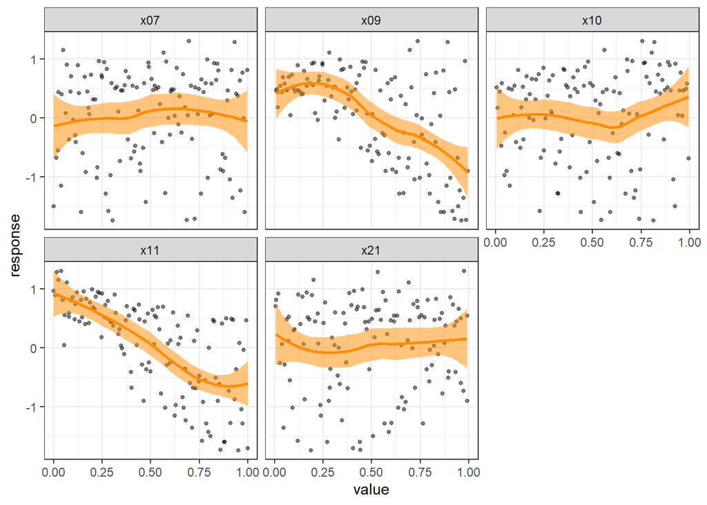

```r
df_start %>% tibble::rowid_to_column() %>%
  tidyr::gather(key="key", value = "value", -rowid, -response) %>%
  ggplot(mapping = aes(x = value, y = response)) +
  geom_point(alpha = 0.5, size = 1) +
  geom_smooth(color = "darkorange", fill = "darkorange", alpha = 0.5) +
  facet_wrap(~key) +
  theme_bw()
```

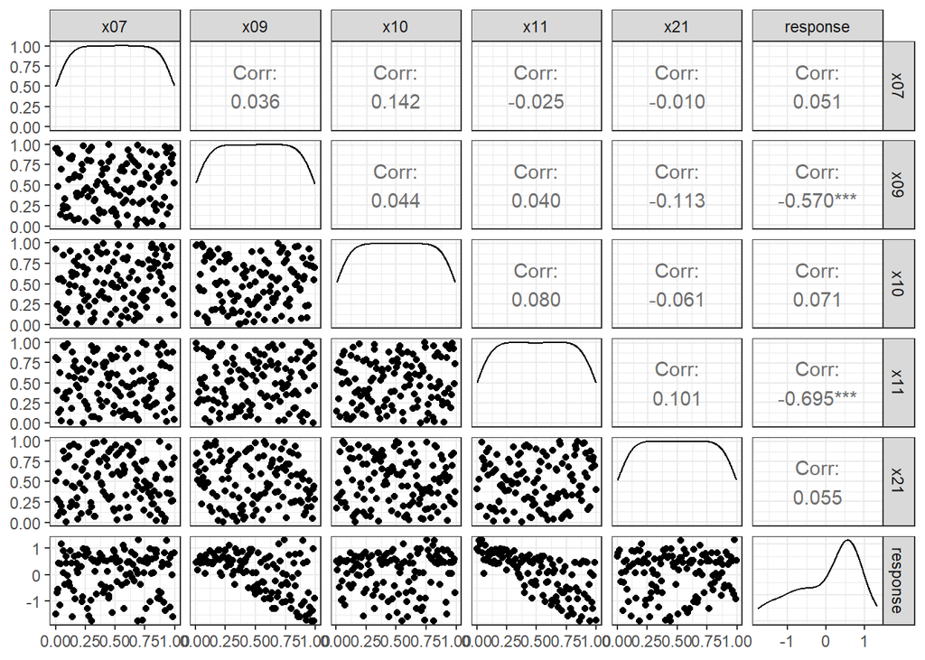

```r
df_start %>%
  GGally::ggpairs() +
  theme_bw()
```

### Use lm() to fit linear models

Model1:

```r
mod01 <- lm(response ~ x07 + x09 + x10 + x11 + x21, data = df_start)
```

Model2:

```r
mod02 <- lm(response ~ (.) ^ 2, data = df_start)
```

Model3:

```r
mod03 <- lm(response ~ (.) + I(x07 ^ 3) + I(x09 ^ 3) + I(x10 ^ 3) + I(x11 ^ 3) + I(x21 ^ 3), data = df_start)
```

Model4:

```r
mod04 <- lm(response ~ I(x07 ^ 2) * x09 + I(x10 ^ 2) * x11 + x21, data = df_start)
```

Model5:

```r
mod05 <- lm(response ~ (.) ^ 3 + I(x07 ^ 2) + I(x09 ^ 2) + I(x10 ^ 2) + I(x11 ^ 2) + I(x21 ^ 2) + I(x07 ^ 3) + I(x09 ^ 3) + I(x10 ^ 3) + I(x11 ^ 3) + I(x21 ^ 3), data = df_start)
```

Model6:

```r
mod06 <- lm(response ~ splines::ns(x09, 4) + splines::ns(x11, 4) + splines::ns(x07, 4) + splines::ns(x10, 4) + splines::ns(x21, 4), data = df_start)
```

```r
purrr::map_dfr(list(mod01, mod02, mod03, mod04, mod05, mod06), broom::glance)
```

```
## # A tibble: 6 x 12
##   r.squared adj.r.squared sigma statistic  p.value    df logLik    AIC    BIC
##       <dbl>         <dbl> <dbl>     <dbl>    <dbl> <dbl>  <dbl>  <dbl>  <dbl>
## 1     0.806         0.798 0.353      98.7 1.21e-40     5  -44.0  102.  122.
## 2     0.952         0.945 0.184     143.  2.13e-64    15   43.0  -52.0  -3.92
## 3     0.825         0.809 0.342      53.6 2.02e-38    10  -37.6   99.3 133.
## 4     0.810         0.799 0.352      71.3 3.08e-39     7  -42.6  103.  129.
## 5     0.982         0.975 0.123     141.  2.98e-64    35  106.  -137.  -32.5
## 6     0.841         0.810 0.342      27.4 1.24e-32    20  -31.6  107.  169.
## # ... with 3 more variables: deviance <dbl>, df.residual <int>, nobs <int>
```

### Which of the 6 models is the best? What performance metric did you use to make your selection?

Cubic response surface methods model (mod05) is the best according to R-squared, sigma BIC and AIC.

### Visualize the coefficient summaries for your best two models. How do they compare?

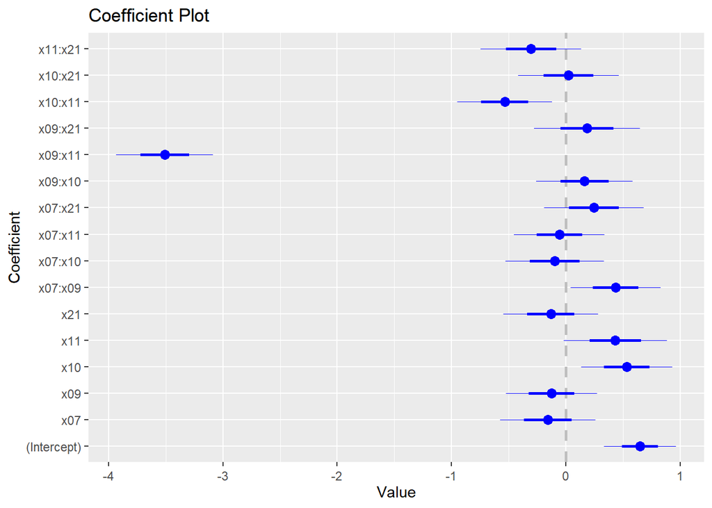

```r
coefplot(mod02)
```

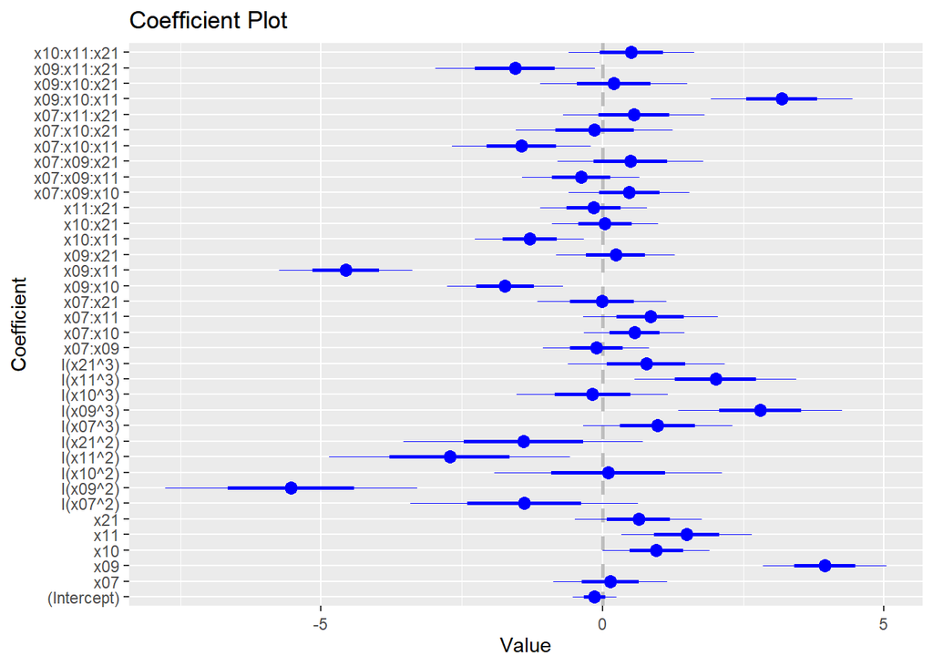

```r
coefplot(mod05)
```

```r
summary(mod05)
```

```
##
## Call:
## lm(formula = response ~ (.)^3 + I(x07^2) + I(x09^2) + I(x10^2) +
##     I(x11^2) + I(x21^2) + I(x07^3) + I(x09^3) + I(x10^3) + I(x11^3) +
##     I(x21^3), data = df_start)
##
## Residuals:
##      Min       1Q   Median       3Q      Max
## -0.34424 -0.06240  0.00467  0.06837  0.31231
##
## Coefficients:
##             Estimate Std. Error t value Pr(>|t|)
## (Intercept) -0.14399    0.19357  -0.744 0.458906
## x07          0.13888    0.50671   0.274 0.784656
## x09          3.94648    0.54792   7.203 1.82e-10 ***
## x10          0.95510    0.47468   2.012 0.047234 *
## x11          1.49329    0.57942   2.577 0.011605 *
## x21          0.63885    0.56355   1.134 0.259994
## I(x07^2)    -1.39574    1.01029  -1.382 0.170576
## I(x09^2)    -5.53513    1.11919  -4.946 3.55e-06 ***
## I(x10^2)     0.09683    1.00970   0.096 0.923815
## I(x11^2)    -2.71800    1.06869  -2.543 0.012708 *
## I(x21^2)    -1.40722    1.06330  -1.323 0.189078
## I(x07^3)     0.97612    0.66354   1.471 0.144795
## I(x09^3)     2.79994    0.72991   3.836 0.000233 ***
## I(x10^3)    -0.18411    0.67194  -0.274 0.784717
## I(x11^3)     2.00496    0.71889   2.789 0.006467 **
## I(x21^3)     0.77326    0.69552   1.112 0.269226
## x07:x09     -0.11500    0.47043  -0.244 0.807443
## x07:x10      0.56569    0.44728   1.265 0.209266
## x07:x11      0.84841    0.59781   1.419 0.159334
## x07:x21     -0.01205    0.57152  -0.021 0.983230
## x09:x10     -1.73372    0.51447  -3.370 0.001113 **
## x09:x11     -4.55878    0.59237  -7.696 1.82e-11 ***
## x09:x21      0.22897    0.52676   0.435 0.664852
## x10:x11     -1.29937    0.48151  -2.699 0.008333 **
## x10:x21      0.04295    0.47330   0.091 0.927901
## x11:x21     -0.16057    0.47683  -0.337 0.737102
## x07:x09:x10  0.47177    0.53516   0.882 0.380395
## x07:x09:x11 -0.38530    0.52038  -0.740 0.461001
## x07:x09:x21  0.49337    0.65020   0.759 0.449979
## x07:x10:x11 -1.44094    0.61864  -2.329 0.022113 *
## x07:x10:x21 -0.14593    0.69520  -0.210 0.834220
## x07:x11:x21  0.55529    0.62587   0.887 0.377350
## x09:x10:x11  3.18509    0.62778   5.074 2.12e-06 ***
## x09:x10:x21  0.19418    0.65260   0.298 0.766745
## x09:x11:x21 -1.55544    0.70757  -2.198 0.030524 *
## x10:x11:x21  0.51136    0.55561   0.920 0.359877
## ---
## Signif. codes:  0 '***' 0.001 '**' 0.01 '*' 0.05 '.' 0.1 ' ' 1
##
## Residual standard error: 0.1232 on 89 degrees of freedom
## Multiple R-squared:  0.9823, Adjusted R-squared:  0.9753
## F-statistic: 140.8 on 35 and 89 DF,  p-value: < 2.2e-16
```

Comparing two plots, x09:x11, x10:x11, x07:x09 and x10 are significant in model02. x09, x10, x11, x09^2, x11^2, x09^3, x11^3, x09:x10, x09:x11, x10:x11, x07:x10:x11, x09:x10:x11 and x09:x11:x21 are significant in model05. x09, x10, x11 as well as their polynomial and their interactions look very important.

### Use Bayesian linear models to fit 2 of the models you fit with lm().

```r
Bay_mod02 <- stan_lm(response ~ (.) ^ 2, data = df_start,
                 prior = R2(location = 0.8),
                 seed = 555)
Bay_mod05 <- stan_lm(response ~ (.) ^ 3 + I(x07 ^ 2) + I(x09 ^ 2) + I(x10 ^ 2) + I(x11 ^ 2) + I(x21 ^ 2) + I(x07 ^ 3) + I(x09 ^ 3) + I(x10 ^ 3) + I(x11 ^ 3) + I(x21 ^ 3), data = df_start,
                 prior = R2(location = 0.8),
                 seed = 555)
```

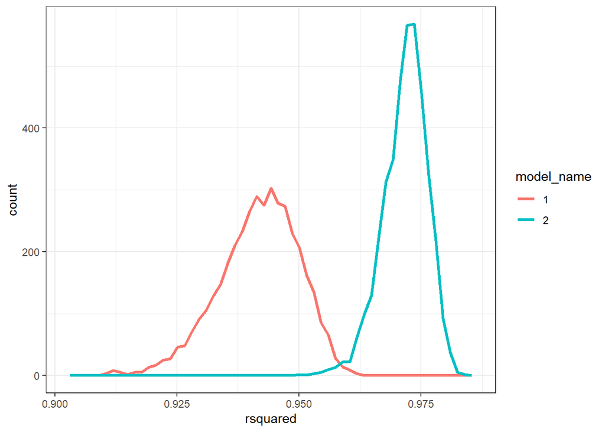

```r
purrr::map2_dfr(list(Bay_mod02, Bay_mod05),
                as.character(1:2),
                function(mod, mod_name){tibble::tibble(rsquared = bayes_R2(mod)) %>%
                    mutate(model_name = mod_name)}) %>%
  ggplot(mapping = aes(x = rsquared)) +
  geom_freqpoly(bins = 55,
                 mapping = aes(color = model_name),
                 size = 1.1) +
  theme_bw()
```

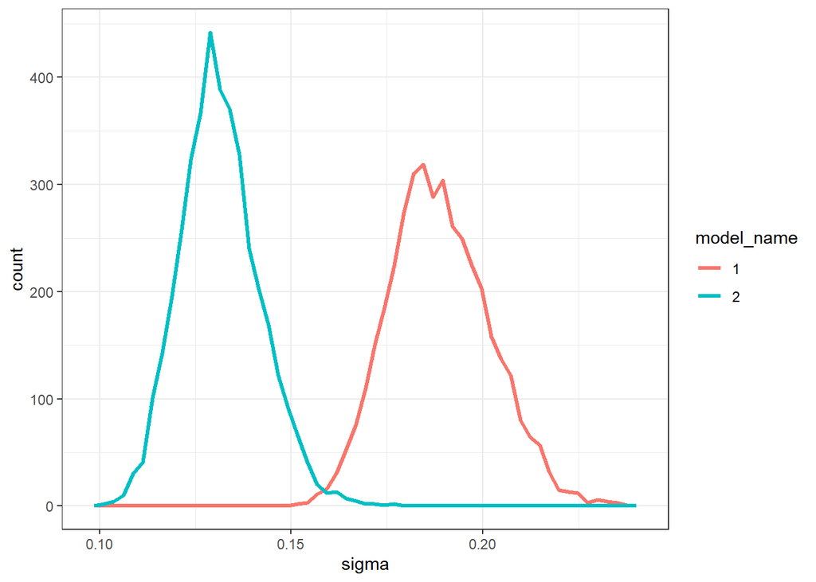

```r
purrr::map2_dfr(list(Bay_mod02, Bay_mod05),
                as.character(1:2),
                function(mod, mod_name){as.data.frame(mod) %>% tibble::as_tibble() %>%
                    select(sigma) %>%
                    mutate(model_name = mod_name)}) %>%
  ggplot(mapping = aes(x = sigma)) +
  geom_freqpoly(bins = 55,
                 mapping = aes(color = model_name),
                 size = 1.1) +
  theme_bw()
```

```r
Bay_mod02$waic <- waic(Bay_mod02)
Bay_mod05$waic <- waic(Bay_mod05)
two_best_models <- stanreg_list(Bay_mod02, Bay_mod05, model_names = c("Pairwise Interactions", "RSM3"))
loo_compare(two_best_models, criterion = "waic")
```

```
## Model comparison based on WAIC:
##                       elpd_diff se_diff
## RSM3                    0.0       0.0
## Pairwise Interactions -36.5      10.4
```

Base on the R-squared, sigma and WAIC, the RMS3 model (Bay_mod05) is the best model.

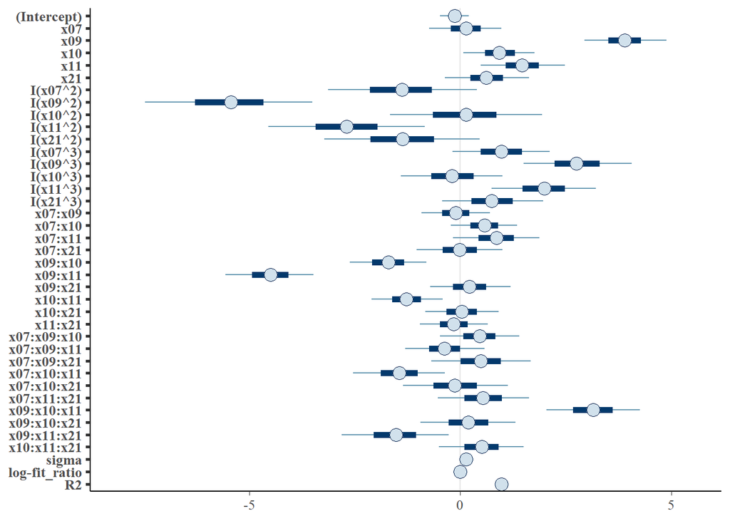

```r
plot(Bay_mod05)
```

### For your best model: study the uncertainty in the noise (residual error), 𝜎. How does the lm() maximum likelihood estimate (MLE) on 𝜎 relate to the posterior uncertainty on 𝜎?

```r
summary(Bay_mod05)
```

```
##
## Model Info:
##  function:     stan_lm
##  family:       gaussian [identity]
##  formula:      response ~ (.)^3 + I(x07^2) + I(x09^2) + I(x10^2) + I(x11^2) +
##     I(x21^2) + I(x07^3) + I(x09^3) + I(x10^3) + I(x11^3) + I(x21^3)
##  algorithm:    sampling
##  sample:       4000 (posterior sample size)
##  priors:       see help('prior_summary')
##  observations: 125
##  predictors:   36
##
## Estimates:
##                 mean   sd   10%   50%   90%
## (Intercept)   -0.1    0.2 -0.4  -0.1   0.1
## x07            0.1    0.5 -0.5   0.1   0.8
## x09            3.9    0.6  3.2   3.9   4.6
## x10            0.9    0.5  0.3   0.9   1.6
## x11            1.5    0.6  0.7   1.5   2.3
## x21            0.6    0.6 -0.2   0.6   1.4
## I(x07^2)      -1.4    1.1 -2.8  -1.4   0.0
## I(x09^2)      -5.5    1.2 -7.0  -5.4  -4.0
## I(x10^2)       0.1    1.1 -1.3   0.1   1.5
## I(x11^2)      -2.7    1.1 -4.1  -2.7  -1.3
## I(x21^2)      -1.4    1.1 -2.8  -1.4   0.0
## I(x07^3)       1.0    0.7  0.1   1.0   1.9
## I(x09^3)       2.8    0.8  1.8   2.8   3.8
## I(x10^3)      -0.2    0.7 -1.1  -0.2   0.7
## I(x11^3)       2.0    0.8  1.0   2.0   2.9
## I(x21^3)       0.8    0.7 -0.2   0.7   1.7
## x07:x09       -0.1    0.5 -0.7  -0.1   0.5
## x07:x10        0.6    0.5  0.0   0.6   1.2
## x07:x11        0.9    0.6  0.1   0.9   1.7
## x07:x21        0.0    0.6 -0.8   0.0   0.8
## x09:x10       -1.7    0.6 -2.4  -1.7  -1.0
## x09:x11       -4.5    0.6 -5.3  -4.5  -3.7
## x09:x21        0.2    0.6 -0.5   0.2   1.0
## x10:x11       -1.3    0.5 -1.9  -1.3  -0.6
## x10:x21        0.0    0.5 -0.7   0.0   0.7
## x11:x21       -0.2    0.5 -0.8  -0.2   0.5
```

[output cut: 50 more lines]

```
## x07:x09:x21   0.0  1.0  5892
## x07:x10:x11   0.0  1.0  4496
## x07:x10:x21   0.0  1.0  4852
## x07:x11:x21   0.0  1.0  4729
## x09:x10:x11   0.0  1.0  6625
## x09:x10:x21   0.0  1.0  4620
## x09:x11:x21   0.0  1.0  5081
## x10:x11:x21   0.0  1.0  5717
## sigma         0.0  1.0  3001
## log-fit_ratio 0.0  1.0  5760
## R2            0.0  1.0  2967
## mean_PPD      0.0  1.0  3736
## log-posterior 0.3  1.0   627
##
## For each parameter, mcse is Monte Carlo standard error, n_eff is a crude measure of effective sample size, and Rhat is the potential scale reduction factor on split chains (at convergence Rhat=1).
```

```r
as.data.frame(Bay_mod05) %>% tibble::as_tibble() %>%
  select(sigma) %>%
  pull() %>%
  quantile(c(0.05, 0.5, 0.95))
```

```
##        5%       50%       95%
## 0.1153699 0.1307300 0.1492184
```

So the 5th quantile of the sigma is 0.1153699, the median is 0.1307300, and the 95th quantile is 0.1492184.

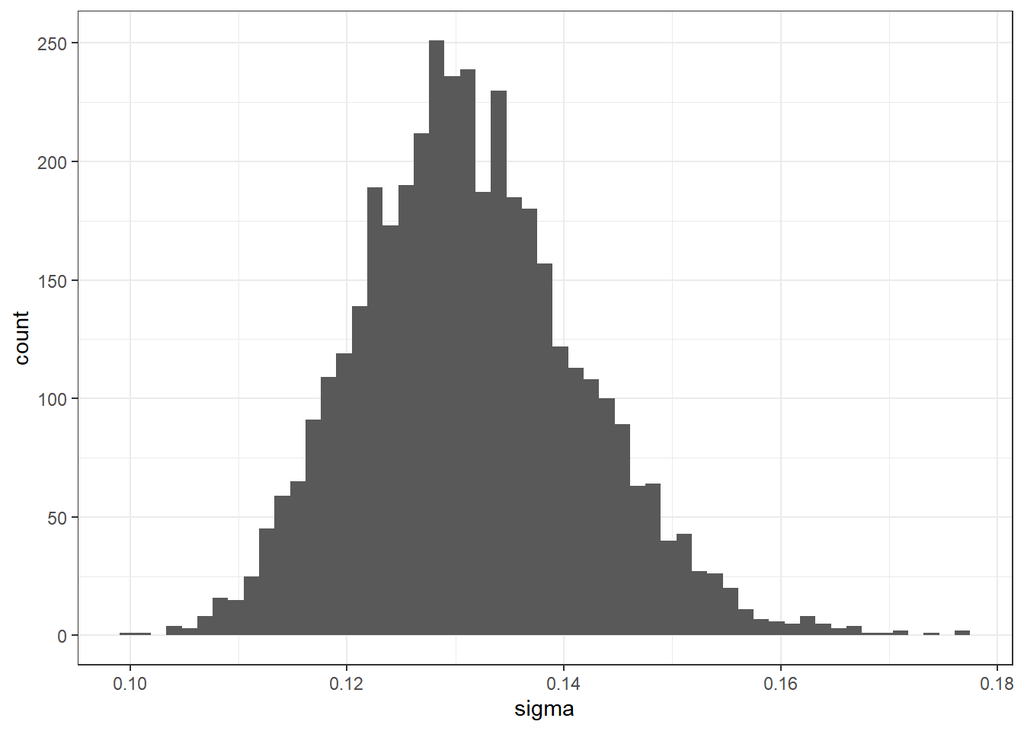

```r
as.data.frame(Bay_mod05) %>% tibble::as_tibble() %>%
  ggplot(mapping = aes(x = sigma)) +
  geom_histogram(bins = 55) +
  theme_bw()
```

```r
summary(mod05)
```

```
##
## Call:
## lm(formula = response ~ (.)^3 + I(x07^2) + I(x09^2) + I(x10^2) +
##     I(x11^2) + I(x21^2) + I(x07^3) + I(x09^3) + I(x10^3) + I(x11^3) +
##     I(x21^3), data = df_start)
##
## Residuals:
##      Min       1Q   Median       3Q      Max
## -0.34424 -0.06240  0.00467  0.06837  0.31231
##
## Coefficients:
##             Estimate Std. Error t value Pr(>|t|)
## (Intercept) -0.14399    0.19357  -0.744 0.458906
## x07          0.13888    0.50671   0.274 0.784656
## x09          3.94648    0.54792   7.203 1.82e-10 ***
## x10          0.95510    0.47468   2.012 0.047234 *
## x11          1.49329    0.57942   2.577 0.011605 *
## x21          0.63885    0.56355   1.134 0.259994
## I(x07^2)    -1.39574    1.01029  -1.382 0.170576
## I(x09^2)    -5.53513    1.11919  -4.946 3.55e-06 ***
## I(x10^2)     0.09683    1.00970   0.096 0.923815
## I(x11^2)    -2.71800    1.06869  -2.543 0.012708 *
## I(x21^2)    -1.40722    1.06330  -1.323 0.189078
## I(x07^3)     0.97612    0.66354   1.471 0.144795
## I(x09^3)     2.79994    0.72991   3.836 0.000233 ***
## I(x10^3)    -0.18411    0.67194  -0.274 0.784717
## I(x11^3)     2.00496    0.71889   2.789 0.006467 **
## I(x21^3)     0.77326    0.69552   1.112 0.269226
## x07:x09     -0.11500    0.47043  -0.244 0.807443
## x07:x10      0.56569    0.44728   1.265 0.209266
## x07:x11      0.84841    0.59781   1.419 0.159334
## x07:x21     -0.01205    0.57152  -0.021 0.983230
## x09:x10     -1.73372    0.51447  -3.370 0.001113 **
## x09:x11     -4.55878    0.59237  -7.696 1.82e-11 ***
## x09:x21      0.22897    0.52676   0.435 0.664852
## x10:x11     -1.29937    0.48151  -2.699 0.008333 **
## x10:x21      0.04295    0.47330   0.091 0.927901
## x11:x21     -0.16057    0.47683  -0.337 0.737102
## x07:x09:x10  0.47177    0.53516   0.882 0.380395
## x07:x09:x11 -0.38530    0.52038  -0.740 0.461001
## x07:x09:x21  0.49337    0.65020   0.759 0.449979
## x07:x10:x11 -1.44094    0.61864  -2.329 0.022113 *
## x07:x10:x21 -0.14593    0.69520  -0.210 0.834220
## x07:x11:x21  0.55529    0.62587   0.887 0.377350
## x09:x10:x11  3.18509    0.62778   5.074 2.12e-06 ***
## x09:x10:x21  0.19418    0.65260   0.298 0.766745
## x09:x11:x21 -1.55544    0.70757  -2.198 0.030524 *
## x10:x11:x21  0.51136    0.55561   0.920 0.359877
## ---
## Signif. codes:  0 '***' 0.001 '**' 0.01 '*' 0.05 '.' 0.1 ' ' 1
##
## Residual standard error: 0.1232 on 89 degrees of freedom
## Multiple R-squared:  0.9823, Adjusted R-squared:  0.9753
## F-statistic: 140.8 on 35 and 89 DF,  p-value: < 2.2e-16
```

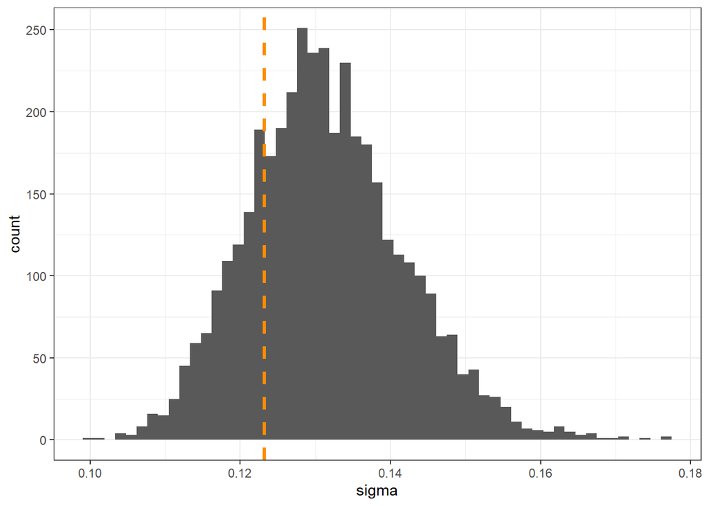

```r
as.data.frame(Bay_mod05) %>% tibble::as_tibble() %>%
  ggplot(mapping = aes(x = sigma)) +
  geom_histogram(bins = 55) +
  geom_vline(xintercept = stats::sigma(mod05),
             color = "darkorange", linetype = "dashed", size = 1.1) +
  theme_bw()
```

Base on the plot, the lm() maximum likelihood estimate (MLE) on sigma is not exactly located at the median of the posterior uncertainty interval, but still within the 90% posterior uncertainty interval.

### Make predictions with the top 2 Bayesian models in order to visualize the trends of the continuous output with respect to the inputs.

```r
viz_grid <- expand.grid(x07 = 0.1,
                        x09 = c(0.1, 0.2, 0.3, 0.4, 0.5),
                        x10 = c(0.1, 0.3, 0.9),
                        x11 = seq(0, 1, length.out = 25),
                        x21 = 0.1,
                        KEEP.OUT.ATTRS = FALSE,
                        stringsAsFactors = FALSE) %>%
  as.data.frame() %>% tibble::as_tibble()

viz_grid %>% glimpse()
```

```
## Rows: 375
## Columns: 5
## $ x07 <dbl> 0.1, 0.1, 0.1, 0.1, 0.1, 0.1, 0.1, 0.1, 0.1, 0.1, 0.1, 0.1, 0.1, 0~
## $ x09 <dbl> 0.1, 0.2, 0.3, 0.4, 0.5, 0.1, 0.2, 0.3, 0.4, 0.5, 0.1, 0.2, 0.3, 0~
## $ x10 <dbl> 0.1, 0.1, 0.1, 0.1, 0.1, 0.3, 0.3, 0.3, 0.3, 0.3, 0.9, 0.9, 0.9, 0~
## $ x11 <dbl> 0.00000000, 0.00000000, 0.00000000, 0.00000000, 0.00000000, 0.0000~
## $ x21 <dbl> 0.1, 0.1, 0.1, 0.1, 0.1, 0.1, 0.1, 0.1, 0.1, 0.1, 0.1, 0.1, 0.1, 0~
```

Make prediction with both models:

```r
tidy_predict <- function(mod, xnew)
{
  pred_df <- predict(mod, xnew, interval = "confidence") %>%
    as.data.frame() %>% tibble::as_tibble() %>%
    dplyr::select(pred = fit, ci_lwr = lwr, ci_upr = upr) %>%
    bind_cols(predict(mod, xnew, interval = 'prediction') %>%
                as.data.frame() %>% tibble::as_tibble() %>%
                dplyr::select(pred_lwr = lwr, pred_upr = upr))

  xnew %>% bind_cols(pred_df)
}
```

```r
pred_lm_02 <- tidy_predict(mod02, viz_grid)
pred_lm_05 <- tidy_predict(mod05, viz_grid)
```

Let’s first check the prediction on lm_mod02.

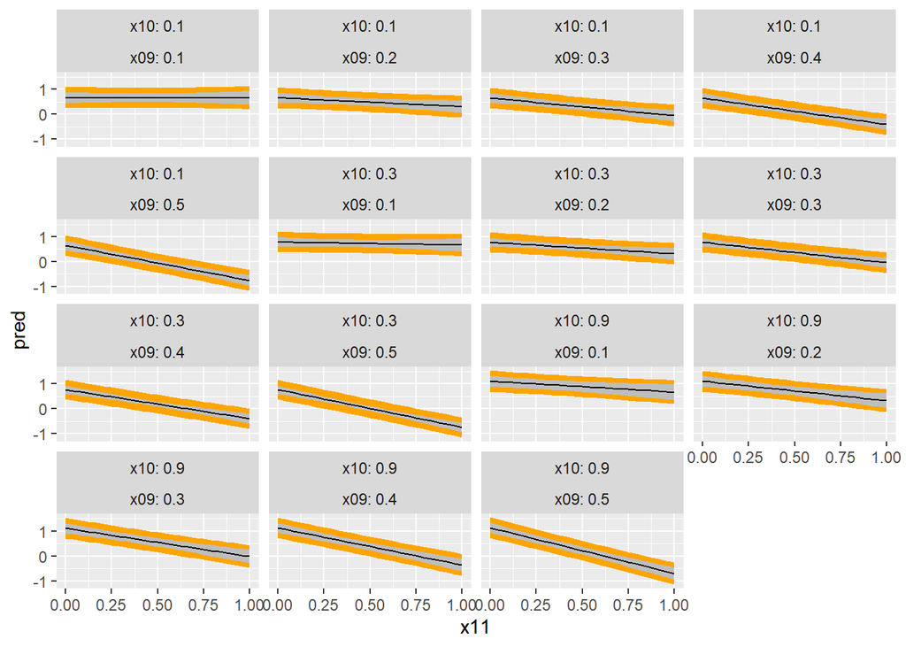

```r
pred_lm_02 %>%
  ggplot(mapping = aes(x = x11)) +
  geom_ribbon(mapping = aes(ymin = pred_lwr, ymax = pred_upr), fill = 'orange') +
  geom_ribbon(mapping = aes(ymin = ci_lwr, ymax = ci_upr), fill = 'grey') +
  geom_line(mapping = aes(y = pred)) +
  facet_wrap(x10~x09, labeller = "label_both")
```

The three variables are learned quite well.

Then let’s check lm_mod05.

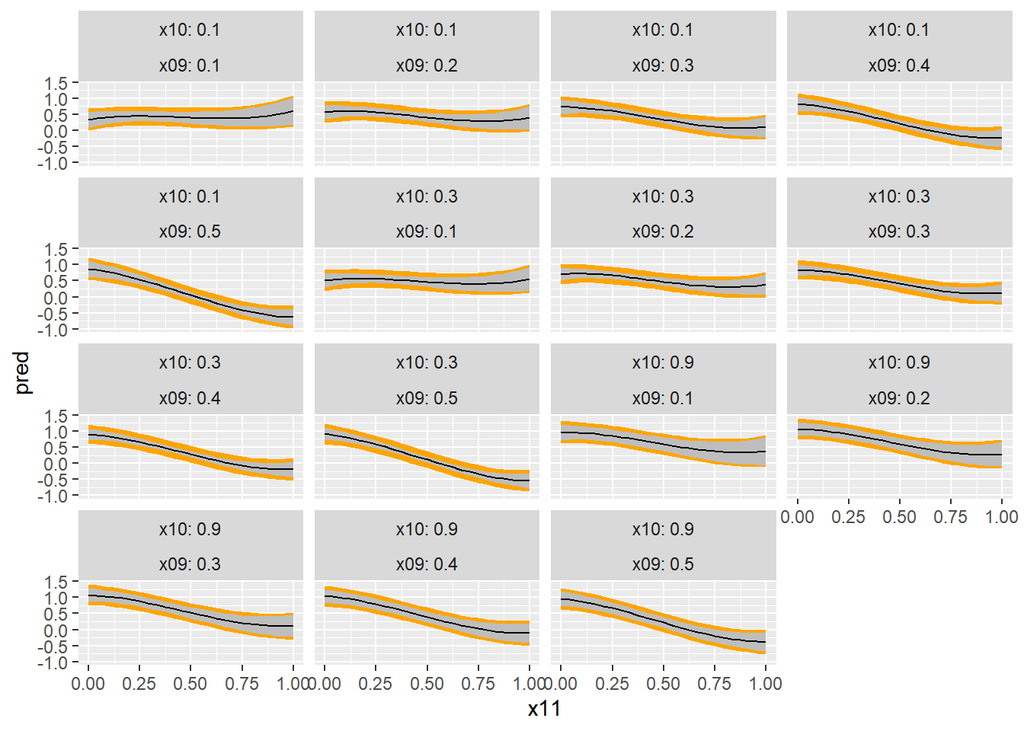

```r
pred_lm_05 %>%
  ggplot(mapping = aes(x = x11)) +
  geom_ribbon(mapping = aes(ymin = pred_lwr, ymax = pred_upr), fill = 'orange') +
  geom_ribbon(mapping = aes(ymin = ci_lwr, ymax = ci_upr), fill = 'grey') +
  geom_line(mapping = aes(y = pred)) +
  facet_wrap(x10~x09, labeller = "label_both")
```

The three variables are learned quite well.

From the plots, the predictive trends are pretty similar between the top 2 models I selected. x09 and x11 are correspond to minimizing the continuous output. I’m confident.